# Relatório 02 - Validação de Distribuições Amostrais no Contexto da Análise de Variância (ANOVA)

Kaleb Aquino Mileib

10/04/2025

# 1 Introdução

Na engenharia mecatrônica, especialmente no ramo automotivo, é comum realizar experimentos para comparar o desempenho de diferentes tecnologias ou configurações de componentes. A Análise de Variância (ANOVA) é uma ferramenta estatística essencial para comparar médias de diferentes grupos e verificar se as variações observadas são estatisticamente significativas.

Para que os resultados da ANOVA sejam válidos, é necessário garantir que certas suposições sejam atendidas, especialmente sobre a distribuição das amostras. Este documento mostra como estudar e validar distribuições amostrais usando R, com aplicação em um experimento automotivo.

# 2 Exemplo Prático: Comparação de Consumo entre Tipos de Motores

Imagine um experimento em que estamos avaliando três tipos diferentes de motores (Motor A, Motor B e Motor C) instalados em veículos semelhantes. O objetivo é verificar se há diferença significativa no consumo de combustível (km/L) entre os três grupos.

## 2.1 Simulação dos Dados

```
##       km_l motor
## 1 14.21976     A
## 2 14.38491     A
## 3 15.27935     A
## 4 13.84231     B
## 5 13.87757     B
## 6 14.82904     B
## 7 15.38437     C
## 8 14.69398     C
## 9 14.92526     C
```

Tabela de Consumo por Tipo de Motor

| km_l | motor |
| --- | --- |
| 14.21976 | A |
| 14.38491 | A |
| 15.27935 | A |
| 13.84231 | B |
| 13.87757 | B |
| 14.82904 | B |
| 15.38437 | C |
| 14.69398 | C |
| 14.92526 | C |

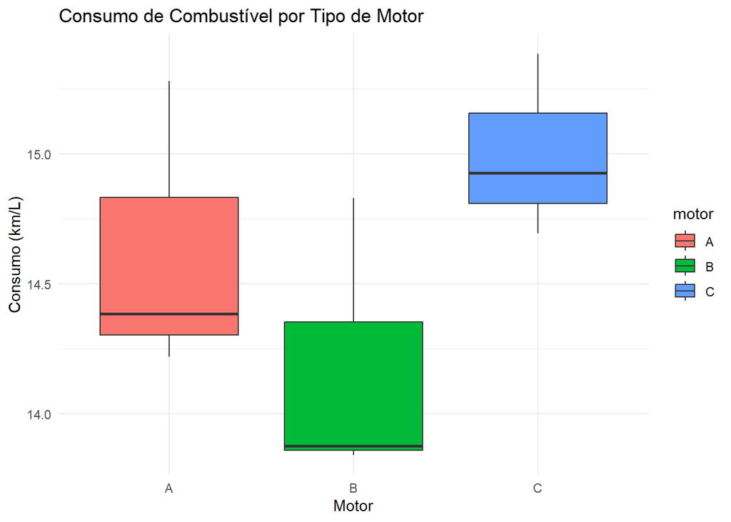

## 2.2 Normalidade dos resíduos

A ANOVA assume que os resíduos seguem uma distribuição normal. Podemos verificar isso com o teste de Shapiro-Wilk e com um gráfico QQ-plot. Neste exemplo, foram gerados 10 valores de cada motor.

```
##
##  Shapiro-Wilk normality test
##
## data:  residuos
## W = 0.9699, p-value = 0.5365
```

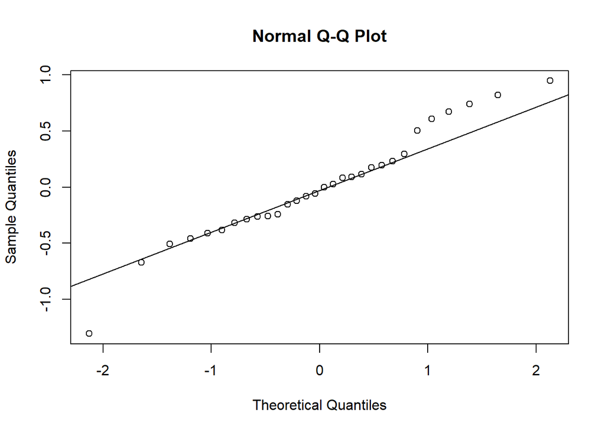

## 2.3 Homogeneidade de variâncias

Outra suposição é a homogeneidade das variâncias entre os grupos. Podemos verificar isso com o teste de Levene.

```
## Levene's Test for Homogeneity of Variance (center = median)
##       Df F value Pr(>F)
## group  2  0.0671 0.9358
##        6
```

Aplicando ANOVA - Se o p-valor do teste F for menor que 0.05, rejeitamos a hipótese nula de que todas as médias são iguais.

```
##             Df Sum Sq Mean Sq F value   Pr(>F)
## motor2       2  6.129  3.0644   12.19 0.000169 ***
## Residuals   27  6.786  0.2513
## ---
## Signif. codes:  0 '***' 0.001 '**' 0.01 '*' 0.05 '.' 0.1 ' ' 1
```

Teste Post-hoc (Tukey) Se houver diferença significativa, o teste de Tukey ajuda a identificar quais grupos são diferentes entre si.

```
##   Tukey multiple comparisons of means
##     95% family-wise confidence level
##
## Fit: aov(formula = km_l2 ~ motor2, data = consumo2)
##
## $motor2
##           diff         lwr         upr     p adj
## B-A -0.6121396 -1.16802547 -0.05625382 0.0287143
## C-A  0.4928636 -0.06302219  1.04874945 0.0896022
## C-B  1.1050033  0.54911745  1.66088910 0.0001064
```

# 3 Conclusão

Essas técnicas são fundamentais para qualquer engenheiro que precise comparar desempenhos de sistemas ou componentes, como motores, sensores ou algoritmos de controle, sob diferentes condições.